# Final Project

Broghan OConnor

2024-02-27

The aim of this exercise is to seamlessly employ scraping techniques for data analysis on public sentiments towards Star Wars. Various rating platforms, including IMdb and Rotten Tomatoes, have assigned rankings to the Star Wars movies. My objective was to juxtapose IMdb’s numerical evaluations with sentiment analysis rankings of commented reviews.The overarching purpose was to investigate whether the expressed emotions in the reviews align with the corresponding numerical ratings.

The journey began by extracting IMdb movie comments for each Star Wars installment through scraping. Subsequently, I delved into sentiment analysis to discern the emotional tone embedded in these comments. This process seeks to quantify the emotional essence of each film for a nuanced ranking.

To delve even deeper, I applied Topic Modeling to identify the most recurrent words and topics within the movie comments. This multifaceted approach aims to provide a comprehensive understanding of both numerical rankings and emotional nuances, contributing to a more thorough analysis of people’s perceptions of the Star Wars saga.

This is commented out as it is the scraping process. It was already completed and saved to a file.

```r
# load proper packages
#from playwright.sync_api import sync_playwright, Playwright
#import pandas as pd
#import re
```

```r
# create a list of star_wars links to their review pages
#star_wars_links=[
  #'https://www.imdb.com/title/tt0120915/reviews',
  #'https://www.imdb.com/title/tt0121765/reviews/?ref_=tt_ql_2',
  #'https://www.imdb.com/title/tt0121766/reviews/?ref_=tt_ql_2',
  #'https://www.imdb.com/title/tt0076759/reviews/?ref_=tt_ql_2',
 # 'https://www.imdb.com/title/tt0080684/reviews/?ref_=tt_ql_2',
  #'https://www.imdb.com/title/tt0086190/reviews/?ref_=tt_ql_2',
 # 'https://www.imdb.com/title/tt2488496/reviews/?ref_=tt_ql_2',
  #'https://www.imdb.com/title/tt2527336/reviews/?ref_=tt_ql_2',
  #'https://www.imdb.com/title/tt2527338/reviews/?ref_=tt_ql_2',
  #'https://www.imdb.com/title/tt3748528/reviews/?ref_=tt_ql_2',
  #'https://www.imdb.com/title/tt3778644/reviews/?ref_=tt_ql_2',
  #'https://www.imdb.com/title/tt1185834/reviews/?ref_=tt_ql_2'
  #]

# create an empty list eventually will store data
#all_reviews = []*len(star_wars_links)
```

```r
# run a for loop for each star wars link
#for x in (star_wars_links):
 # page.goto(x) # go to the star wars link page

 # i = 1 # click the load more button for certain amount of times to load more comments
 # while i < 10:
  #  page.get_by_text('Load More').click()
  #  i += 1
  #link_count = page.locator("css=.text").count()
  #comments_list = [] * link_count
#Scraping - locate where and scrape it
 # for i in range(link_count):
   # comments = page.locator("css=.text").nth(i).inner_text()
    #ratings = page.locator("css=.rating-other-user-rating").nth(i)
   # ratings_count = ratings.count()
   # if ratings_count == 1: # in place in case no rating is present
   #   ratings_score = ratings.inner_text()
   # elif ratings_count == 0:
   #   ratings_score = None # generate a table that has comments, rating, and show title
   # comments_list.append(pd.DataFrame(data = {'comment': [comments], 'rating': #[ratings_score], 'show': x}))

  #all_reviews.append(pd.concat(comments_list)) # rearrange the table

#all_reviews_output = pd.concat(all_reviews)

# save file
#all_reviews_output.to_csv("C:/Users/broco/OneDrive/Documents/R/Notre Dame/Unstructured Data/starwars_reviews_actual.csv")

# close the browser
#chrome.close()

#pw.stop()
```

Load in all the various libraries.

```r
library(lexicon)
library(sentimentr)
library(stringr)
library(dplyr)
library(tidyr)
```

Data was scraped earlier and is just added here. List is made to be able to identify which link corresponded to which Star Wars Episode.

```r
starwars_movies <- data.frame(
  show = c('https://www.imdb.com/title/tt0120915/reviews',
  'https://www.imdb.com/title/tt0121765/reviews/?ref_=tt_ql_2',
  'https://www.imdb.com/title/tt0121766/reviews/?ref_=tt_ql_2',
  'https://www.imdb.com/title/tt0076759/reviews/?ref_=tt_ql_2',
  'https://www.imdb.com/title/tt0080684/reviews/?ref_=tt_ql_2',
  'https://www.imdb.com/title/tt0086190/reviews/?ref_=tt_ql_2',
  'https://www.imdb.com/title/tt2488496/reviews/?ref_=tt_ql_2',
  'https://www.imdb.com/title/tt2527336/reviews/?ref_=tt_ql_2',
  'https://www.imdb.com/title/tt2527338/reviews/?ref_=tt_ql_2',
  'https://www.imdb.com/title/tt3748528/reviews/?ref_=tt_ql_2',
  'https://www.imdb.com/title/tt3778644/reviews/?ref_=tt_ql_2',
  'https://www.imdb.com/title/tt1185834/reviews/?ref_=tt_ql_2'),
  name = c("ep1", "ep2", "ep3",
           "ep4","ep5", "ep6",
           "ep7", "ep8", "ep9",
           "solo", "r1", "cw")
  )

# load in data
reviews <- read.csv("C:/Users/broco/OneDrive/Documents/R/Notre Dame/Unstructured Data/starwars_reviews_actual.csv")

# pull only reviews that had shows identified.
reviews <- reviews[5928:12873,]

#Join together the table.
reviews <- dplyr::left_join(reviews, starwars_movies, by = "show")
```

General Text Cleaning

```r
  reviews$comment <- reviews$comment %>%
    str_replace_all("\n", " ") %>%
    str_replace_all("(\\[.*?\\])", "") %>%
    str_squish() %>%
    gsub("([a-z])([A-Z])", "\\1 \\2", .) %>%
    tolower()
```

Begin Sentiment Analysis

```r
# format sentences into get sentences form
  comment_sentences <- get_sentences(reviews$comment)

  # Calculate sentiment scores
  sent_score <- sentiment(comment_sentences,
                          polarity_dt = lexicon::hash_sentiment_jockers_rinker)

  # Group each comment back together and calculate the mean sentiment score
  reviews$Sent_score <- aggregate(sent_score$sentiment ~ sent_score$element_id, FUN = mean)

  # reformat the data frame
reviews <- unnest(reviews,  Sent_score,  names_sep = "_")
```

Make a data frame that is just the average of each episode.

```r
summarized <- aggregate(reviews$`Sent_score_sent_score$sentiment` ~ reviews$name, FUN = mean)
```

Library plotting packages

```r
library(ggplot2)
library(ggridges)
```

This graph attempts to show density of sentiment scores. However, they are too overlapped to really tell anything from them.

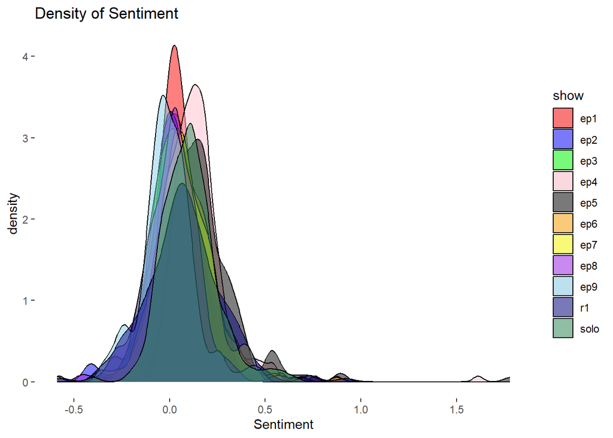

```r
reviews$show <- as.factor(reviews$show) # Convert response to factor for plotting
g_1 <- ggplot(reviews, aes(x = `Sent_score_sent_score$sentiment`, fill = name)) + # Set x as mean radius and fill as diagnosis
  geom_density(alpha = 0.5) + # Select density plot and set transperancy (alpha)
    theme_set(theme_bw(base_size = 22) ) + # Set theme and text size
  theme(panel.grid.major = element_blank(), # Remove grid
        panel.grid.minor = element_blank(), # Remove grid
        panel.border = element_blank(), # Remove grid
        panel.background = element_blank()) + # Remove grid
  labs(x = "Sentiment", title = "Density of Sentiment",
       fill = "show") + # Set labels
  scale_fill_manual(values = c("ep1" = "red", "ep2" = "blue","ep3" = "green","ep4" = "pink","ep5" = "black","ep6" = "orange","ep7" = "yellow","ep8" = "purple","ep9" = "skyblue","solo" = "seagreen","r1" = "navy"), # Set fill colors manually
                    labels = c("1" = "Malignant", "0" = "Benign")) # Set labels for fill
g_1 # Generate plot
```